# Explore Loan Data by Lanmixue Mao (Michelle)

The dataset is comprised of 81 variables and contains 113937 entries. The variable that are explored in the dataset are the following Term : Amount of month customers opted for loan

LoanStatus : Current status of the loan like chargedoff, completed, defauted etcâ¦

EstimatedEffectiveYield : Yield of lenders from borrowers minus the processing fee and late fines

ProsperScore : Risk Factor score from 1 to 10. 10 being least risky

BorrowerAPR : The Borrowerâs Annual Percentage Rate (APR) for the loan.

BorrowerRate : The Borrowerâs interest rate for this loan.

ListingCategory..numeric. : Prosper rating for borrowers in numbers

EmploymentStatus : Current type of employment

Occupation : Occupation of borrower at the time of listing

EmploymentStatusDuration : How long the employee has been employed

IsBorrowerHomeowner : Does the borrower owns house at the time of listing (True & False)

ProsperRating..Alpha. : Prosper rating for borrowers in alphabets

IncomeVerifiable : If the income of the borrower is verifiable at the time of listing (True & False)

StatedMonthlyIncome : Monthly income of the borrower

MonthlyLoanPayment : Monthly loan payment amount

Recommendations : Recommendations the borrowers has at the time of listing

DebtToIncomeRatio : The debt to income ratio of the borrower at the time the credit profile was pulled.

LoanOriginalAmount : Original amount of the loan

LoanOriginationQuarter : Quarter of the month when loan was originated

A basic exploration of the datset would give the following information

```
##  [1] "ListingKey"
##  [2] "ListingNumber"
##  [3] "ListingCreationDate"
##  [4] "CreditGrade"
##  [5] "Term"
##  [6] "LoanStatus"
##  [7] "ClosedDate"
##  [8] "BorrowerAPR"
##  [9] "BorrowerRate"
## [10] "LenderYield"
## [11] "EstimatedEffectiveYield"
## [12] "EstimatedLoss"
## [13] "EstimatedReturn"
## [14] "ProsperRating..numeric."
## [15] "ProsperRating..Alpha."
```

[output cut: 66 more lines]

```
##                    ListingKey     ListingNumber
##  17A93590655669644DB4C06:     6   Min.   :      4
##  349D3587495831350F0F648:     4   1st Qu.: 400919
##  47C1359638497431975670B:     4   Median : 600554
##  8474358854651984137201C:     4   Mean   : 627886
##  DE8535960513435199406CE:     4   3rd Qu.: 892634
##  04C13599434217079754AEE:     3   Max.   :1255725
##  (Other)                :113912
##                     ListingCreationDate  CreditGrade         Term
##  2013-10-02 17:20:16.550000000:     6          :84984   Min.   :12.00
##  2013-08-28 20:31:41.107000000:     4   C      : 5649   1st Qu.:36.00
##  2013-09-08 09:27:44.853000000:     4   D      : 5153   Median :36.00
##  2013-12-06 05:43:13.830000000:     4   B      : 4389   Mean   :40.83
##  2013-12-06 11:44:58.283000000:     4   AA     : 3509   3rd Qu.:36.00
##  2013-08-21 07:25:22.360000000:     3   HR     : 3508   Max.   :60.00
##  (Other)                      :113912   (Other): 6745
##                  LoanStatus                  ClosedDate
##  Current              :56576                      :58848
##  Completed            :38074   2014-03-04 00:00:00:  105
##  Chargedoff           :11992   2014-02-19 00:00:00:  100
##  Defaulted            : 5018   2014-02-11 00:00:00:   92
##  Past Due (1-15 days) :  806   2012-10-30 00:00:00:   81
##  Past Due (31-60 days):  363   2013-02-26 00:00:00:   78
##  (Other)              : 1108   (Other)            :54633
##   BorrowerAPR       BorrowerRate     LenderYield
##  Min.   :0.00653   Min.   :0.0000   Min.   :-0.0100
##  1st Qu.:0.15629   1st Qu.:0.1340   1st Qu.: 0.1242
##  Median :0.20976   Median :0.1840   Median : 0.1730
##  Mean   :0.21883   Mean   :0.1928   Mean   : 0.1827
##  3rd Qu.:0.28381   3rd Qu.:0.2500   3rd Qu.: 0.2400
##  Max.   :0.51229   Max.   :0.4975   Max.   : 0.4925
##  NA's   :25
##  EstimatedEffectiveYield EstimatedLoss   EstimatedReturn
##  Min.   :-0.183          Min.   :0.005   Min.   :-0.183
##  1st Qu.: 0.116          1st Qu.:0.042   1st Qu.: 0.074
##  Median : 0.162          Median :0.072   Median : 0.092
##  Mean   : 0.169          Mean   :0.080   Mean   : 0.096
##  3rd Qu.: 0.224          3rd Qu.:0.112   3rd Qu.: 0.117
##  Max.   : 0.320          Max.   :0.366   Max.   : 0.284
##  NA's   :29084           NA's   :29084   NA's   :29084
```

[output cut: 193 more lines]

```
##  Min.   :    0.00                Min.   :0.7000   Min.   : 0.00000
##  1st Qu.:    0.00                1st Qu.:1.0000   1st Qu.: 0.00000
##  Median :    0.00                Median :1.0000   Median : 0.00000
##  Mean   :   25.14                Mean   :0.9986   Mean   : 0.04803
##  3rd Qu.:    0.00                3rd Qu.:1.0000   3rd Qu.: 0.00000
##  Max.   :21117.90                Max.   :1.0125   Max.   :39.00000
##
##  InvestmentFromFriendsCount InvestmentFromFriendsAmount   Investors
##  Min.   : 0.00000           Min.   :    0.00            Min.   :   1.00
##  1st Qu.: 0.00000           1st Qu.:    0.00            1st Qu.:   2.00
##  Median : 0.00000           Median :    0.00            Median :  44.00
##  Mean   : 0.02346           Mean   :   16.55            Mean   :  80.48
##  3rd Qu.: 0.00000           3rd Qu.:    0.00            3rd Qu.: 115.00
##  Max.   :33.00000           Max.   :25000.00            Max.   :1189.00
##
```

> The prosper loan data can allow me to explore: 1) The difference in borrower APR, borrower rate and lender yield. This shows the difference about what the actual interest rate the borrower haven. 2) By examining the relationship between borrower income and loan payment, we can see how likely the borrower can repay a debt. 3) Other information: general borrower credit status, credit risk analysis.

# Univariate Plots Section

> Basic Loan Information

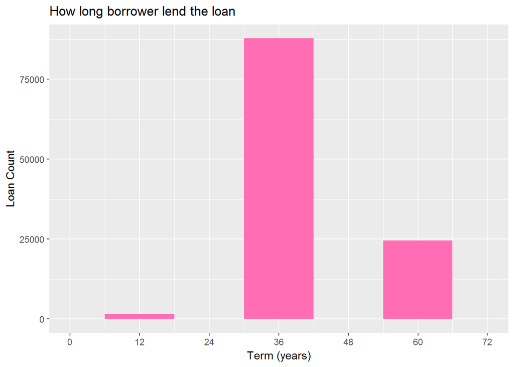

```
##    Min. 1st Qu.  Median    Mean 3rd Qu.    Max.
##   12.00   36.00   36.00   40.83   36.00   60.00
```

We can see that people normally lend the loan around 4,000, also 10,000 and 15,000 are also the popular loan amount for borrowers. This frequency plot is positively skewed but appeared small peaks in every 5,000.

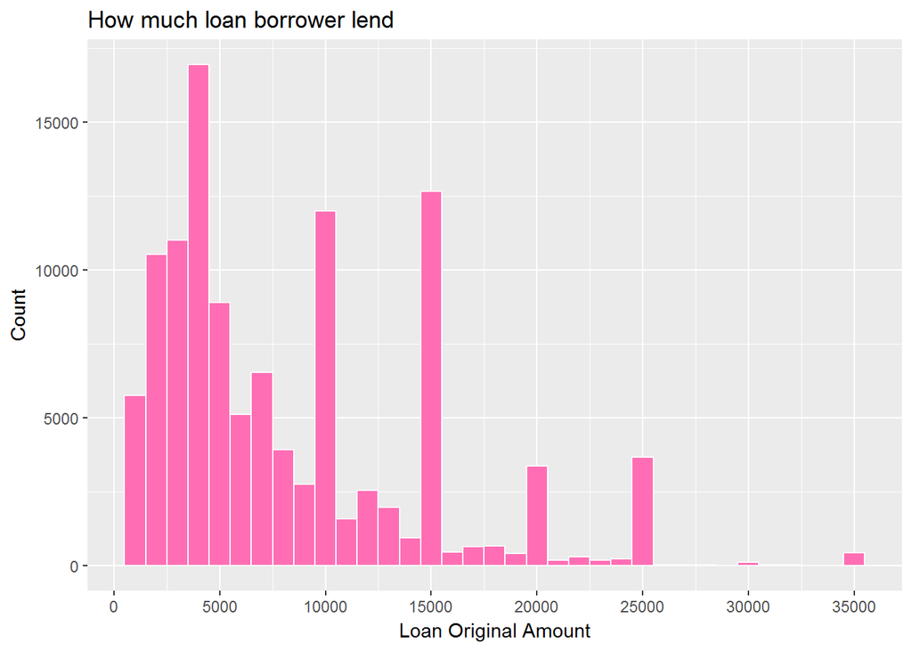

> Basic Borrower Information

Now let’s dive into basic borrower info!

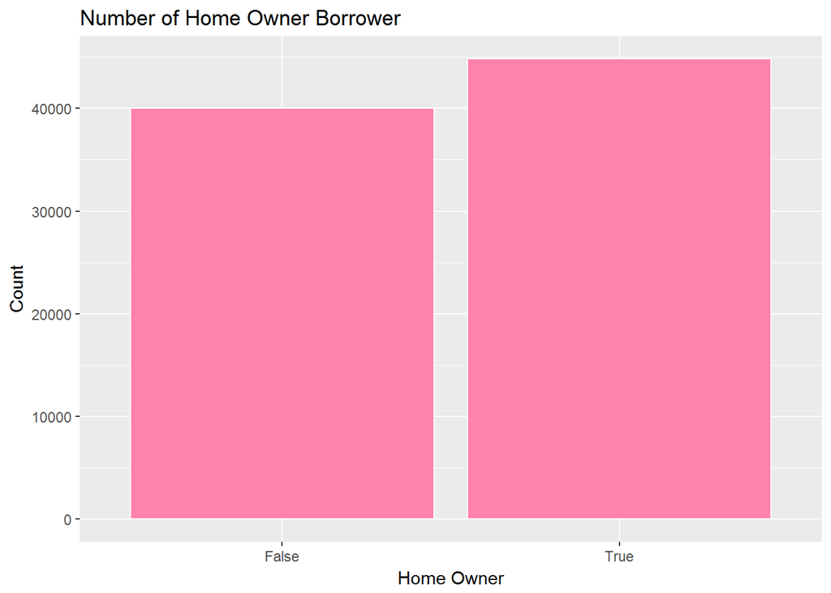

Over half borrowers are home owner which shows the most of the loan borrower has strong debt paying ability.

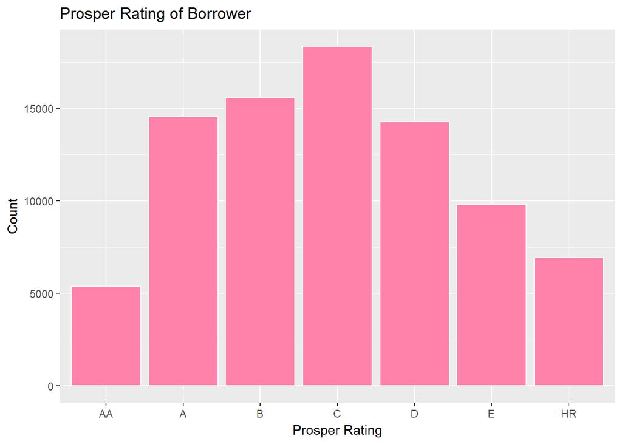

Prosper has seven loan grades called Prosper Ratings: AA, A, B, C, D, E and HR where AA is the lowest risk down to HR which actually stands for high risk.

Except for empty values, the distribution of the ordinal variable has a bell-like shape. âCâ is the most frequent rating in our data and the highest (AA) and the lowest (HR) rating are less common comparing with other ratings in between.

Missing values are surprisingly high. After done the research, I found the Prosper Rating only exists after July 2009. Cross-validated from the loan original date, our data approved my assumption.

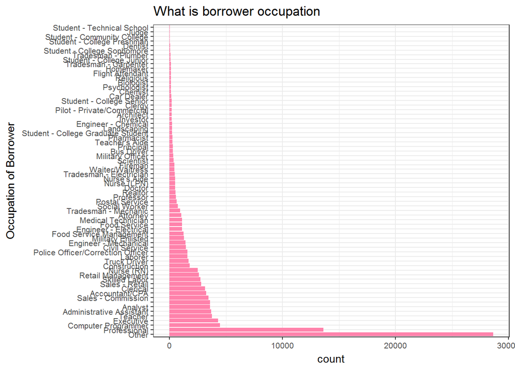

Apart from other occupations, professional occupies a large part of the count. Why loan providers prefer to lend the loan to professional? The reason behind is they have stable and high income compared to others whilst they work on more techniqual job, which show the strong debt paying ability.

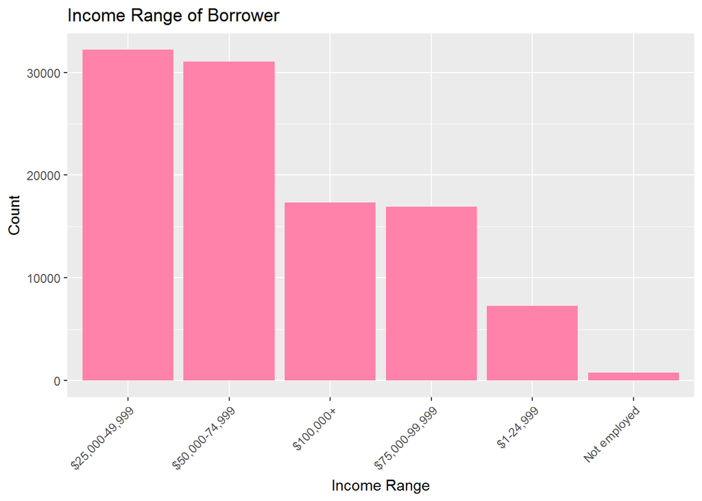

From income perspective, we can see most borrower’s income range is $25,000 - 49,999, the second top is the income range $50,000 - 74,999. This can explain that most people who has an income range $25,000 - 49,999 is the new graduate or young professional, they have a very strong buying power to purchase their first home or car.

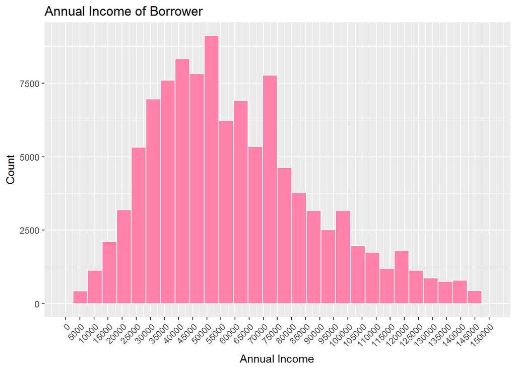

Further, we look at the anuual income of the borrower, this positive skewed frequency plot shows the result as same as the frequency income range plot and repeatively confirms the strong buying power coming from young professionals.

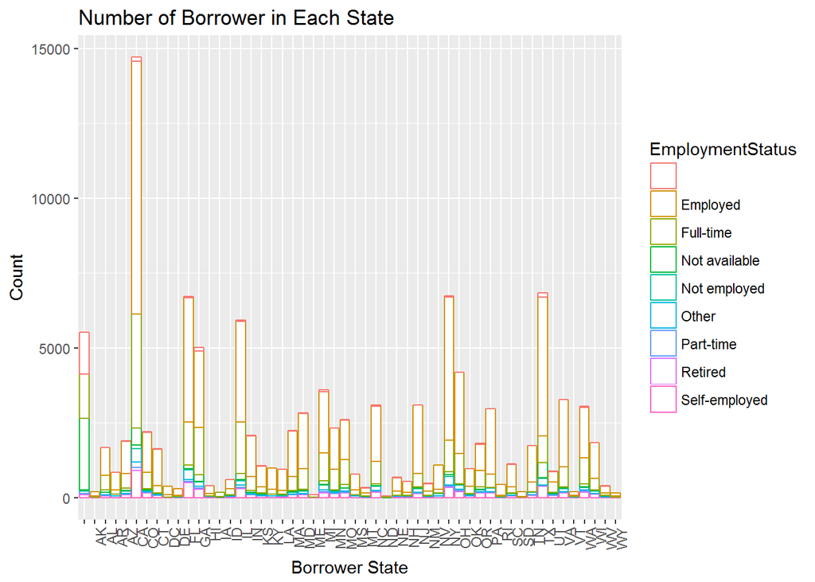

We also care about which state has most borrower. The highest number of borrower is in CA, and it demonstrates that the California consumers have some of the higest levels of debt in the country. Moreover, the following Texas, New York and Florida can also be seen as a big loan market.

> Credit History

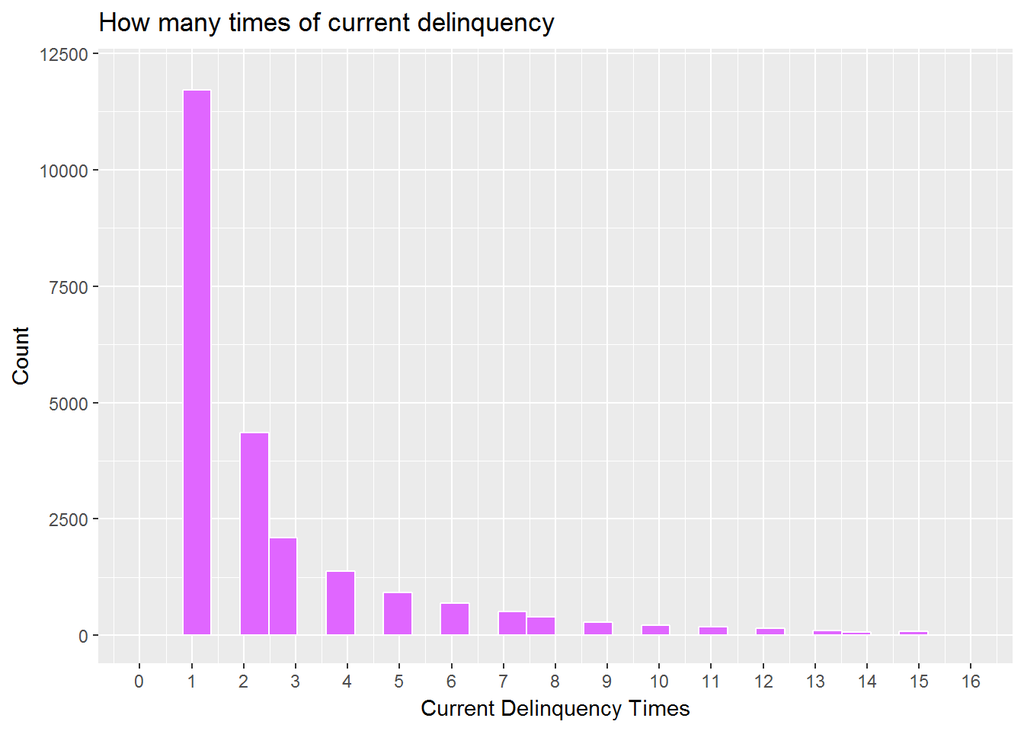

Large proportion of borrowers only occurs one delinquency record. It normally because they forget to pay the annual fee for the credit card, or because they forget to repay one month loan.

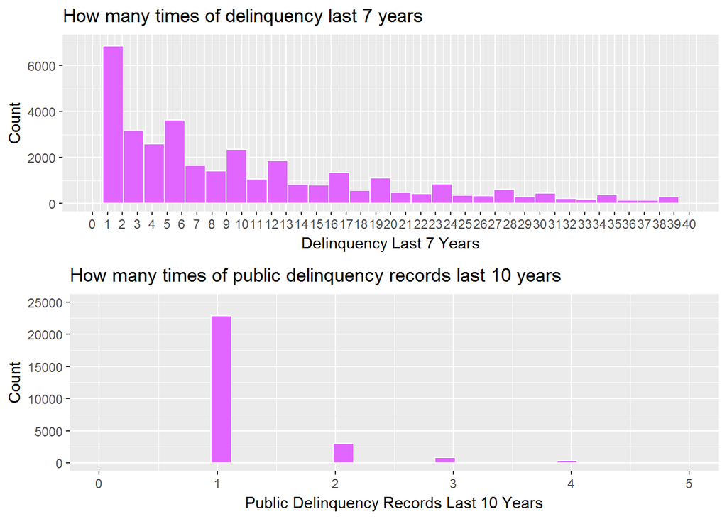

By checking the delinquency records last 7 years and public delinquency records last 10 years, it appears that having one delinquency records still the highest. But it’s strange to see few borrowers have more than 30 times delinquencies.

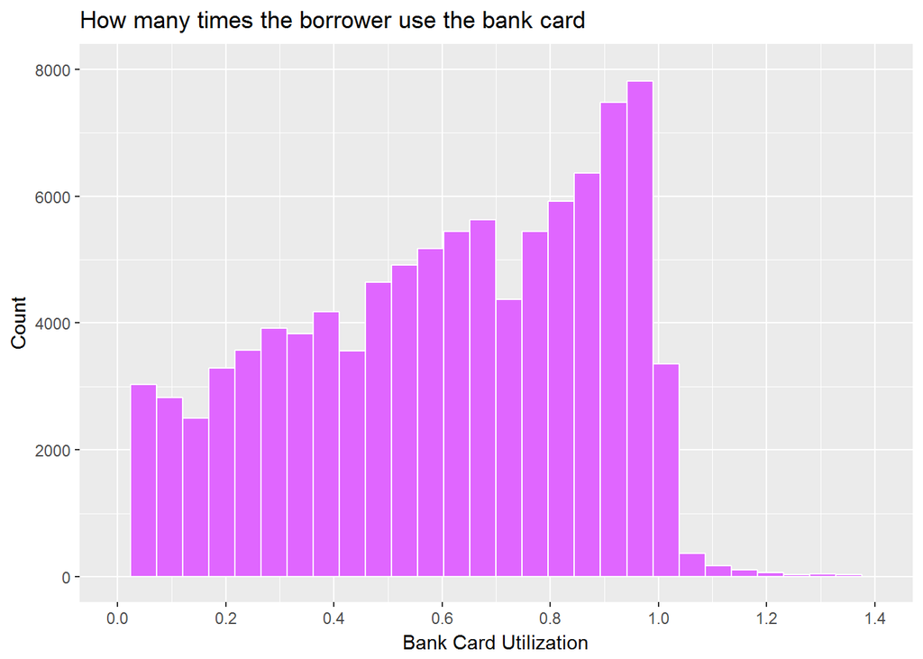

Then how often the borrower use their bank card? We can see the majority bank card utilization frequency is over 0.5 and reach the peak at the 0.9. This can fully demonstrate how much borrower adore the bank card.

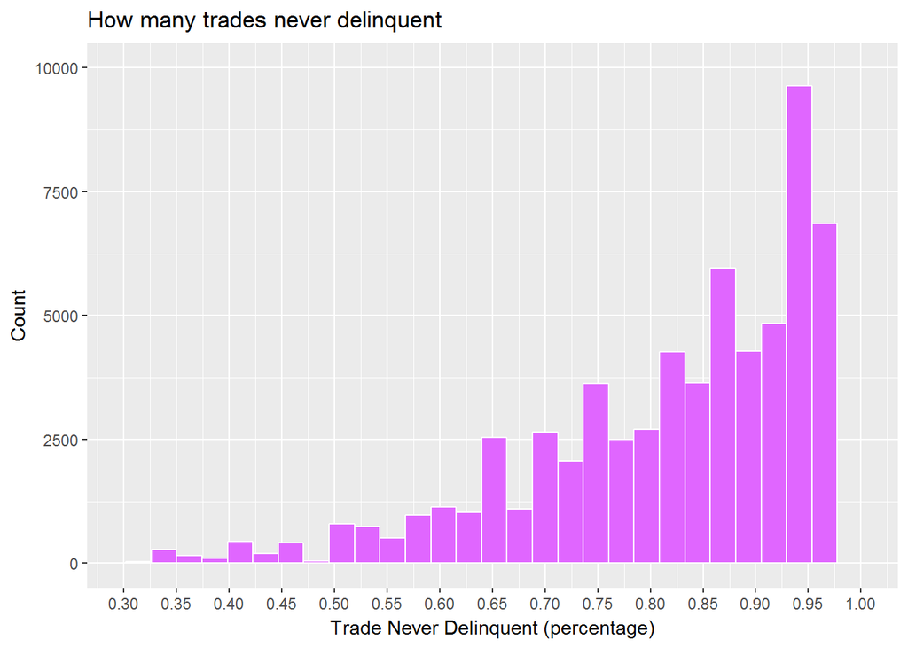

From the records of never delinquent trade, we can tell from this negative skewed histogram that most borrowers keep themselves having a good credit rating and value the lend money. Only few of them has a percentage below 0.50 that we can base on this record to select our loan borrowers and decide whether we want to deal with loan repayment with them or not.

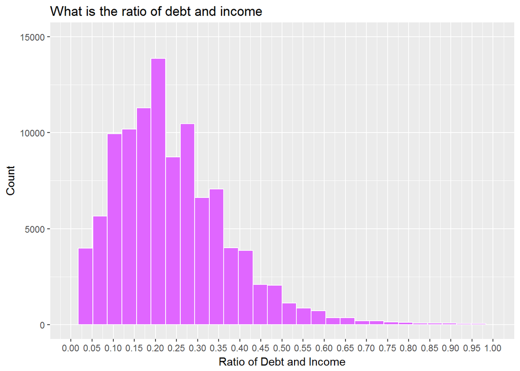

We also want to know how much debt burden that our borrower carry. The distribution of this frequency plot shows that the majority of borrower has a debt and income ratio less than 0.40. The ratio reaches the peak at 0.20. The borrowers’s income can fully cover their debts, and it also obey the rule of “ratio of debt and income should 0.85 or 0.8”.

# Univariate Analysis

### What is the structure of your dataset?

The structure of the dataset covers the different loan interest rates, borrower’s employment status and income, liability ratio, delinquency records, etc.

### What is/are the main feature(s) of interest in your dataset?

Main Features: 1) Interest Rate: BorrowerAPR, BorrowerRate, LendYield 2) Credit Rating: ProsperRating..Alpha., ProsperScore 3) Loan Status: Term, LoanOriginalAmount, BorrowerState, LoanOriginationQuarter 4) Borrower Profile: IncomeRange, DebtToIncomeRatio, EmploymentStatus, MonthlyLoanPayment 5) Delinquency Record: CurrentDelinquencies, DelinquenciesLast7Years, PublicRecordsLast12Months

### What other features in the dataset do you think will help support your investigation into your feature(s) of interest?

1. LP_CustomerPayments, LP_CustomerPrincipalPayments, LP_InterestandFees, LP_ServicesFees Supporting to find how much profit the bank or loan providers can gain
2. IsBorrowerHomeOwner, Occupation Supporting to find borrower’s income source

### Did you create any new variables from existing variables in the dataset?

Created the annual income by calculating the stated monthly income

### Of the features you investigated, were there any unusual distributions? Did you perform any operations on the data to tidy, adjust, or change the form of the data? If so, why did you do this?

I cleaned the income range data, because the not displayed income or null value will affect to see the percentage of each income range. I also excluded several missing values in few variables, such as: DebtToIncomeRatio, BankCardUtilization.

# Bivariate Plots Section

From univariate analysis, I had a big picture about my dataset. In this section, I try to analyse the relationships between variables. My main focus will still on: - Customer Quality - Loan Provider Profitability - Credit Risk

> Customer Quality

Let us take a closer look at our borrowers.

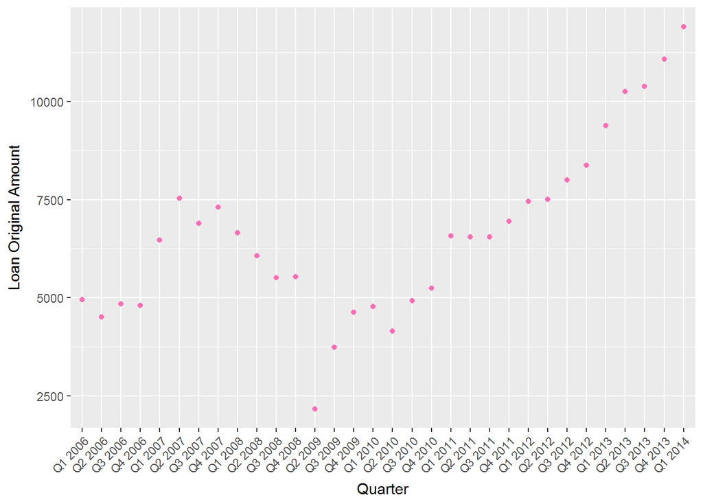

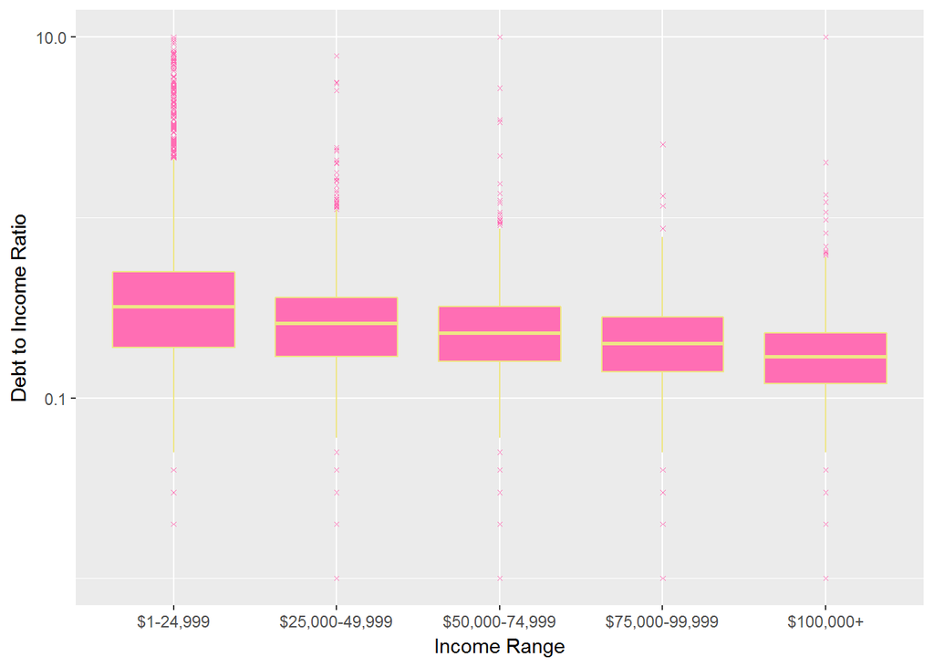

From above plot we can see that people with less income would have heavier mortgage burden. The average debt to income ratio of the $1-24,999 group is slightly higher than $25,000 - 49,999 group. But it’s worth to note that the outliers of the $1- 24,999 group are much more than the others, and it’s strange to see some borrowers have debt to income ratio in 10.0.

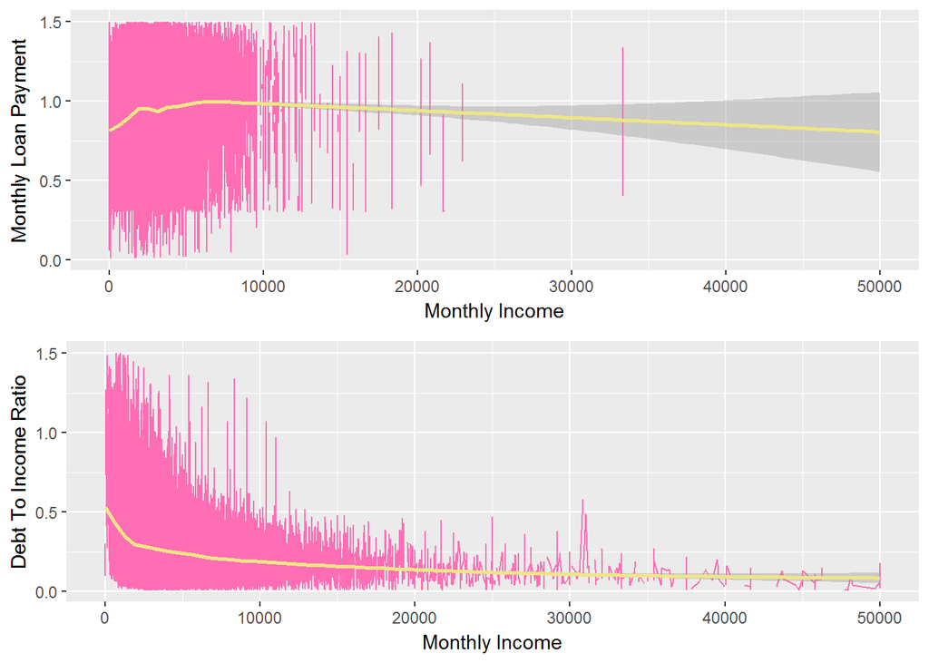

Compared mmonthly loan payment and debt to income ration in terms of monthly income, monthly loan payment is heavily concentrated on monthly income range $0 to $ 10000. However, debt to income ratio shows a positive skewed distribution.

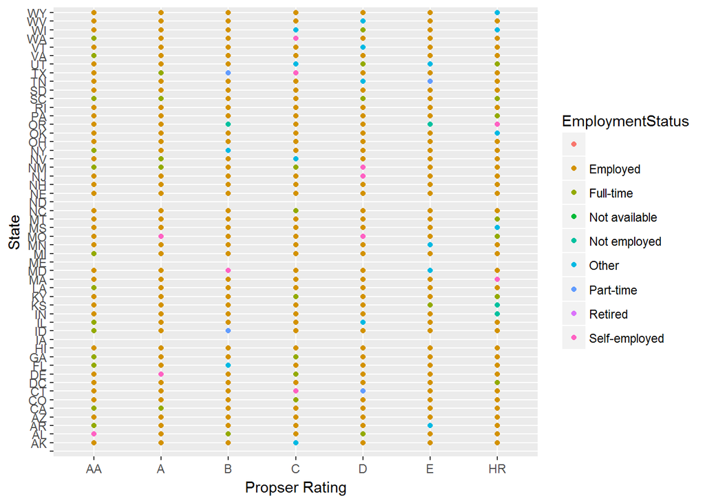

This plot can show us in each state which employment status has what prosper rating. The ND and IA have missing value. Self-employed borrower in MA and OR has the worst propser rating (HR) and highest risk. On the contrary, self-employed borrower in AL has the best prosper rating (AA).

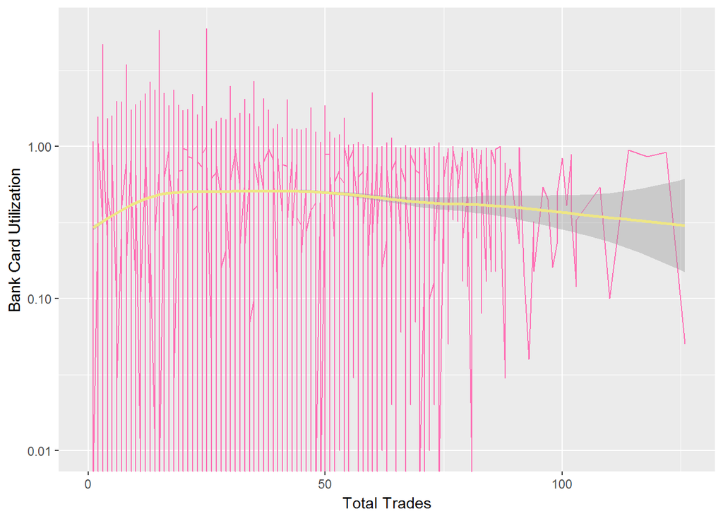

> Bank Profitability

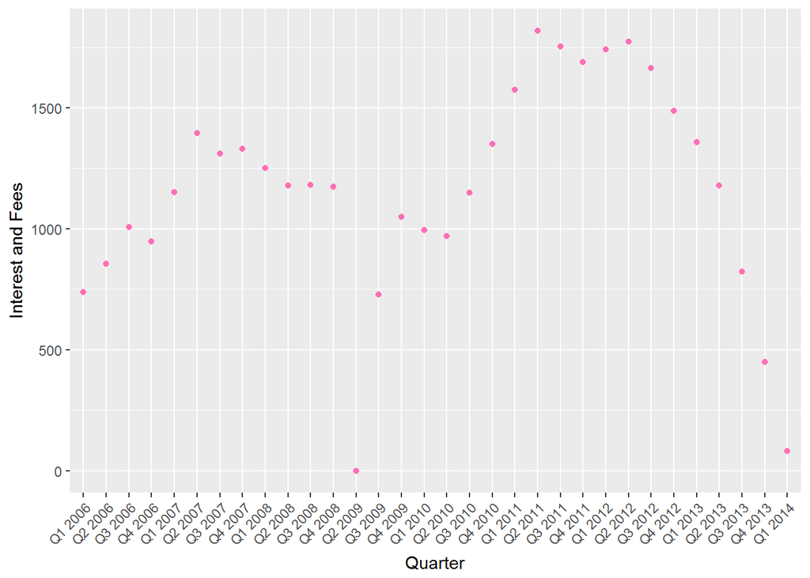

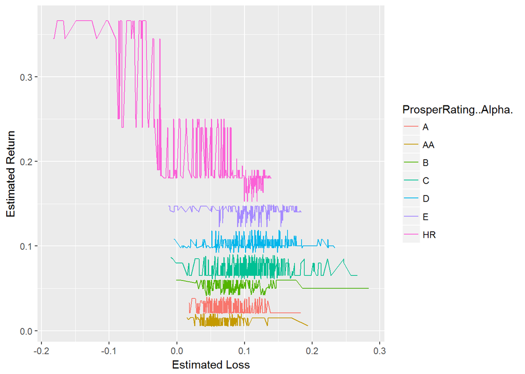

In terms of prosper rating HR, the estimated loss and estimated return are in inverse proportion, because high risk credit has high change to loss the money and be hard to pay back.

> Credit Risk

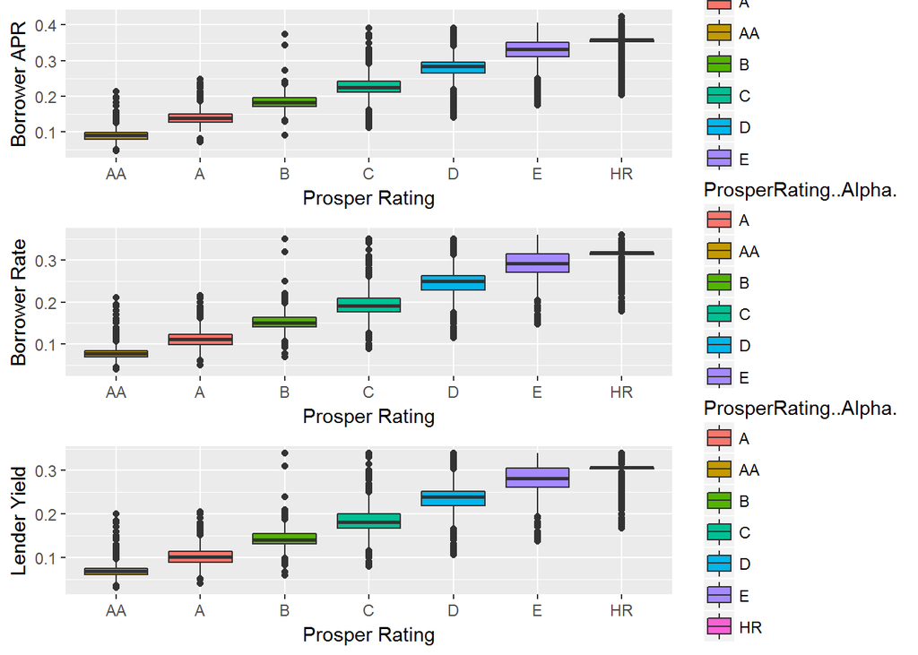

The loan provider adopts different strategies towards borrower who has different prosper rating. In general, the borrower APR, borrower rate and lender yield have similar pattern in terms of prosper rating. Obviously, the highest risk borrowers, the loan provider will charge highest borrower interest rate.

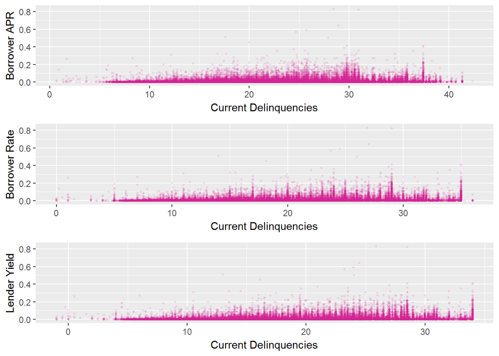

The current delinquencies in terms of borrower APR have a large distribution from 20 to 32. The current delinquencies in terms of borrower rate have a large distribution from 15 to 28, even reach to another peak in 35. The current delinquencies in terms of lender yield have a large distribution from 20 to 28, even reach to another peak in 35. However in general, the rate to cause the delienquencies are below 0.2.

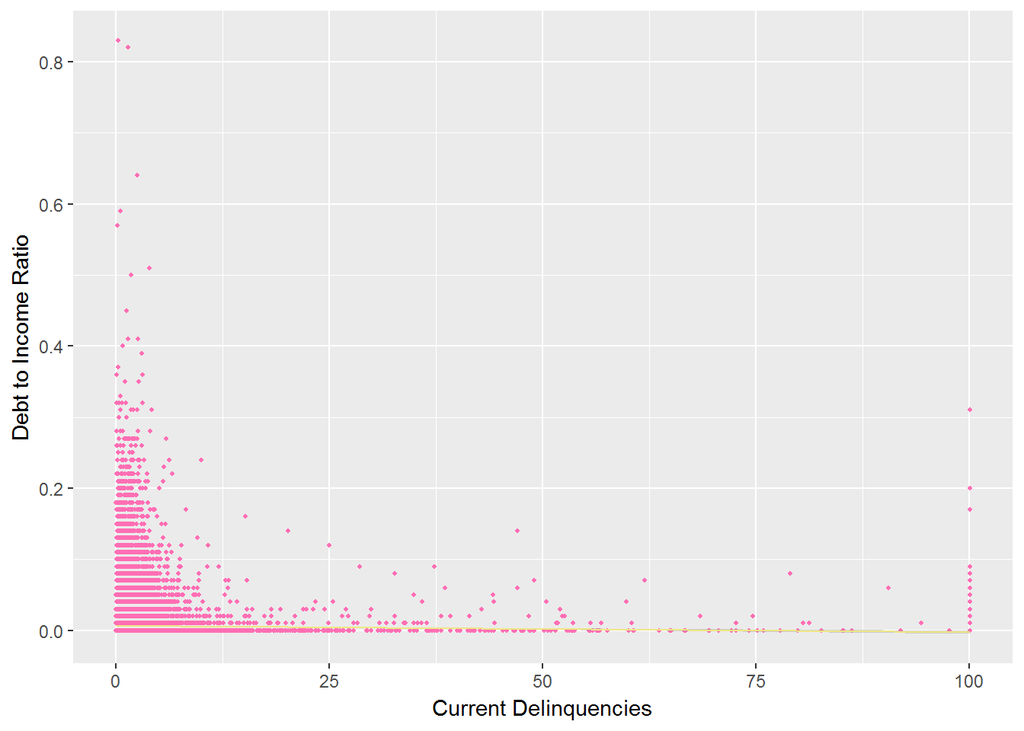

There is a large proposion that the curent delinquency below 10 has a debt to income ratio from 0 to 0.2. But it’s strange to see the 100 times rdelinquencies have a low debt to income ratio.

# Bivariate Analysis

### Talk about some of the relationships you observed in this part of the investigation. How did the feature(s) of interest vary with other features in the dataset?

Borrowers who have lower income would burden heavier debt, according to the debt to income ratio and income range plot.

### Did you observe any interesting relationships between the other features (not the main feature(s) of interest)?

It’s interesting to see the loan original amount growed significantly from 2012 to 2014. But on the contrary, the interest and fees went down dramatically from 2012 to 2014. Even they followed the same pattern as loan original amount before 2012.

### What was the strongest relationship you found?

The prosper rating and borrower rates have the strongest relationship.

# Multivariate Plots Section

In this Section, I will analyse the client quality, loan provider profitability and credit risk together. In each plot, we can have an overall profile regarding to the three aspects.

```
## # A tibble: 50 x 5
##    IncomeRange ProsperRating..Alp~ mean_BorrowerAPR median_Borrower~     n
##    <fct>       <fct>                          <dbl>            <dbl> <int>
##  1 $0          ""                            0.203            0.182    576
##  2 $0          A                             0.129            0.129      2
##  3 $0          B                             0.181            0.183      3
##  4 $0          C                             0.228            0.228      2
##  5 $0          D                             0.285            0.290     15
##  6 $0          E                             0.348            0.352      6
##  7 $0          HR                            0.344            0.354     17
##  8 $1-24,999   ""                            0.206            0.190   2620
##  9 $1-24,999   A                             0.138            0.137    378
## 10 $1-24,999   AA                            0.0889           0.0864    88
## # ... with 40 more rows
```

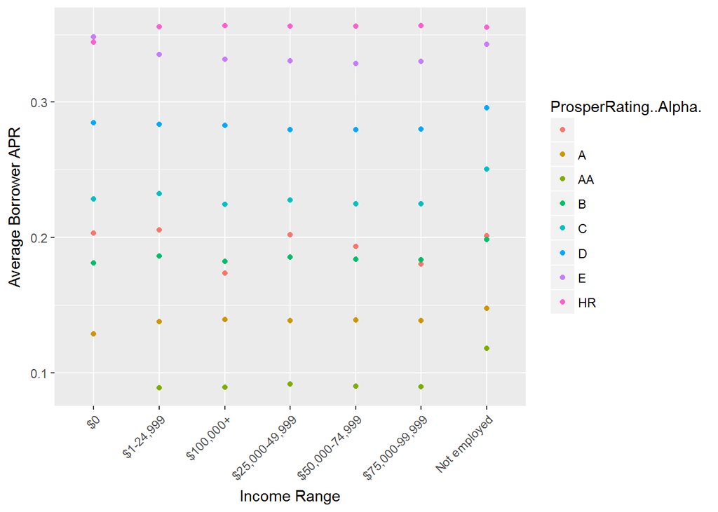

```
## # A tibble: 50 x 4
##    LoanOriginalAmount ProsperRating..Alpha. mean_BorrowerAPR     n
##                 <int> <fct>                            <dbl> <int>
##  1               1000 ""                             NA       2445
##  2               1000 A                               0.137     82
##  3               1000 AA                              0.0746   105
##  4               1000 B                               0.183     16
##  5               1000 C                               0.224    173
##  6               1000 D                               0.279    138
##  7               1000 E                               0.347     99
##  8               1000 HR                              0.374    148
##  9               1001 ""                              0.206      8
## 10               1005 ""                              0.340      2
## # ... with 40 more rows
```

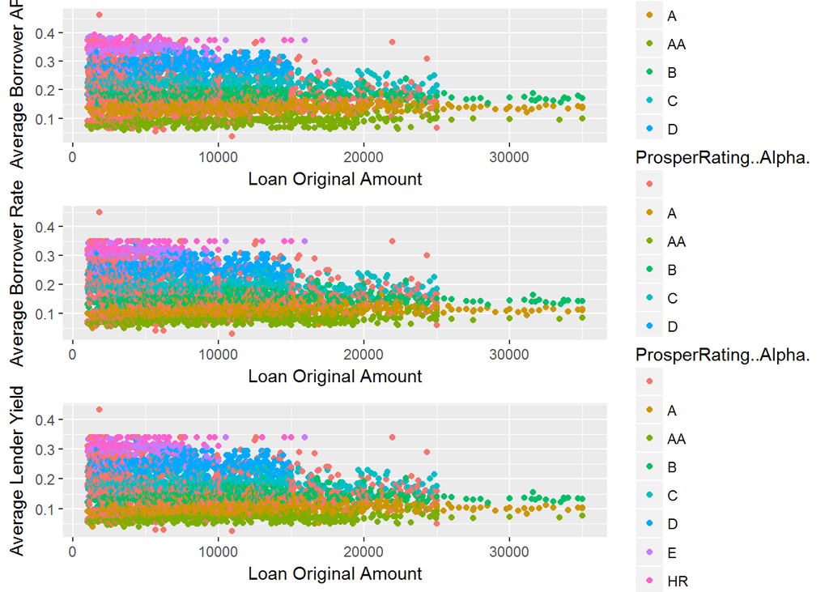

The loan amount provided to different prosper rating customer with different borrower rates is similar. Most of loan amount concentrates on $1000 - $25,000.

```
## # A tibble: 50 x 4
##    LoanOriginalAmount BorrowerState mean_LenderYield     n
##                 <int> <fct>                    <dbl> <int>
##  1               1000 ""                       0.158   521
##  2               1000 AK                       0.176     6
##  3               1000 AL                       0.253    21
##  4               1000 AR                       0.188    20
##  5               1000 AZ                       0.182    55
##  6               1000 CA                       0.187   251
##  7               1000 CO                       0.182    54
##  8               1000 CT                       0.166    21
##  9               1000 DC                       0.199     3
## 10               1000 DE                       0.147     8
## # ... with 40 more rows
```

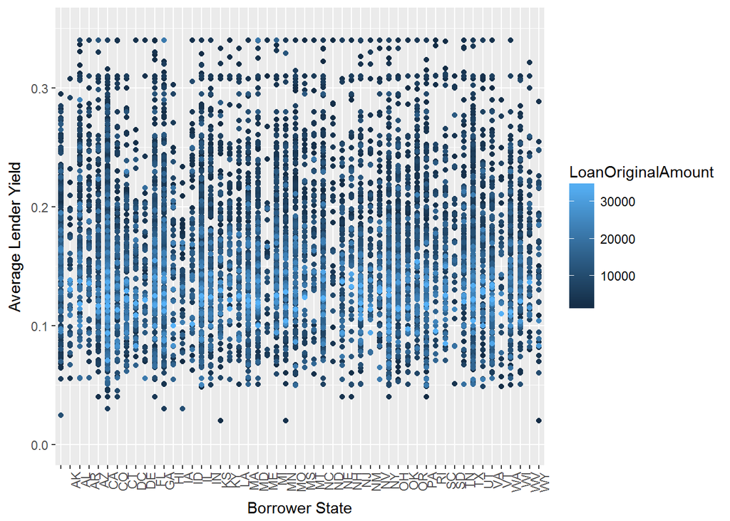

The super high-interest loans have boomed in CA. We also can spot on few other states have very high interest rates and loan amount, such as FL, OR, NY, DC, MA.

```
## # A tibble: 50 x 4
##    IncomeRange DebtToIncomeRatio mean_CurrentDelinquencies     n
##    <fct>                   <dbl>                     <dbl> <int>
##  1 $1-24,999              0.0200                     0.857     7
##  2 $1-24,999              0.0300                     2.20     20
##  3 $1-24,999              0.0400                     1.14     37
##  4 $1-24,999              0.0500                     1.59     64
##  5 $1-24,999              0.0600                     1.77     60
##  6 $1-24,999              0.0700                     1.04     72
##  7 $1-24,999              0.0800                     1.84     87
##  8 $1-24,999              0.0900                     1.10     84
##  9 $1-24,999              0.100                      1.14    102
## 10 $1-24,999              0.110                      1.03    113
## # ... with 40 more rows
```

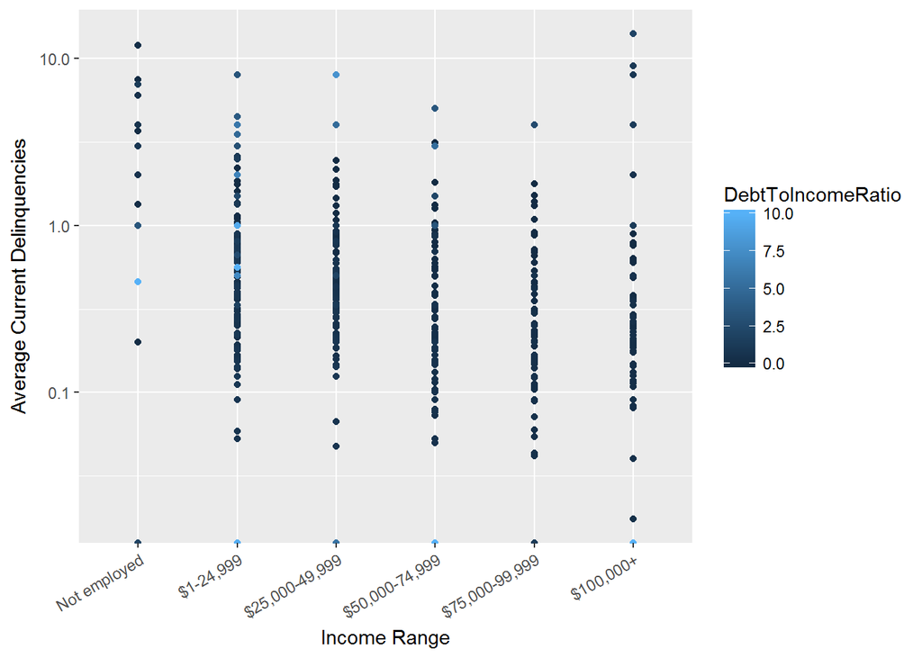

# Multivariate Analysis

### Talk about some of the relationships you observed in this part of the investigation. Were there features that strengthened each other in terms of looking at your feature(s) of interest?

I am glad to find the ralationships between interest rate and borrower who has different income group and prosper rating. It’s meaningful because it gives loan provider some ideas about how to set price of the interest rate in terms of different customer quality.

### Were there any interesting or surprising interactions between features?

I found it is surprising to see borrower who is income is above $100,000 appears to be linked to high levels of delinquent. Before I think they have better capital strength that would not easily to have any delinquency.

# Final Plots and Summary

### Plot One

```
## # A tibble: 8 x 3
##   IncomeRange    mean_LoanOriginalAmount     n
##   <fct>                            <dbl> <int>
## 1 $0                               7411.   621
## 2 $1-24,999                        4274.  7274
## 3 $100,000+                       13073. 17337
## 4 $25,000-49,999                   6178. 32192
## 5 $50,000-74,999                   8675. 31050
## 6 $75,000-99,999                  10366. 16916
## 7 Not displayed                    5170.  7741
## 8 Not employed                     4885.   806
```

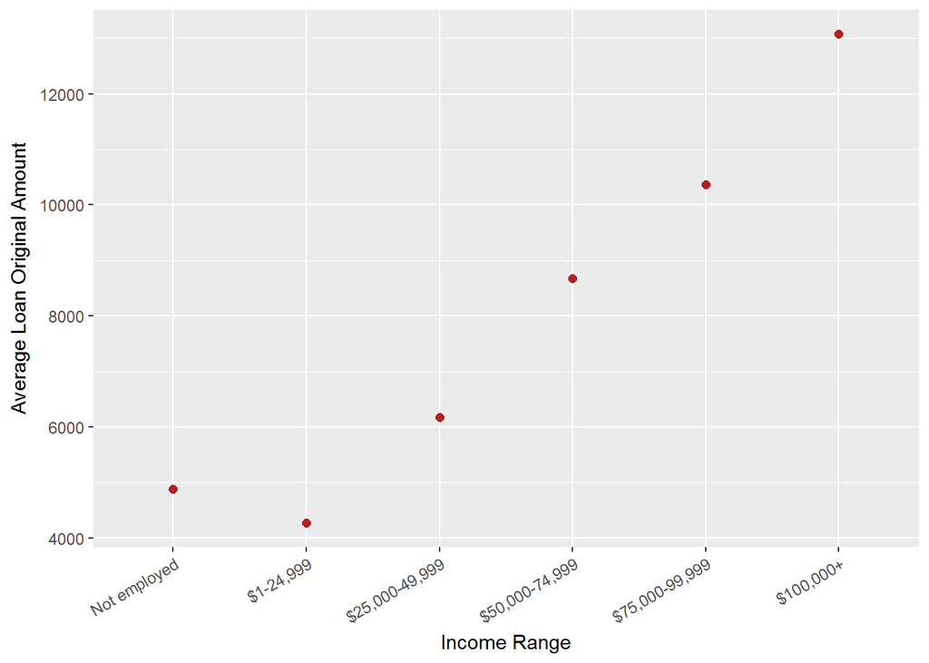

### Description One

Customer Quality

This plot shows the customer quality from two aspects: average loan original amount and income range. Loan provider is interested in how much loan amount they can offer to customer and bacially this customer is in which income range.

### Plot Two

```
## # A tibble: 6 x 10
##   IncomeRange       V1     A      AA     B     C     D     E    HR  ratio
##   <fct>          <dbl> <dbl>   <dbl> <dbl> <dbl> <dbl> <dbl> <dbl>  <dbl>
## 1 $0             0.182 0.129 NA      0.183 0.228 0.290 0.352 0.354 NA
## 2 $1-24,999      0.190 0.137  0.0864 0.183 0.232 0.287 0.340 0.358  0.631
## 3 $100,000+      0.158 0.138  0.0893 0.178 0.223 0.285 0.331 0.358  0.647
## 4 $25,000-49,999 0.184 0.138  0.0906 0.183 0.226 0.284 0.332 0.358  0.657
## 5 $50,000-74,999 0.177 0.138  0.0903 0.181 0.223 0.284 0.326 0.358  0.654
## 6 $75,000-99,999 0.164 0.138  0.0900 0.181 0.223 0.284 0.331 0.358  0.652
```

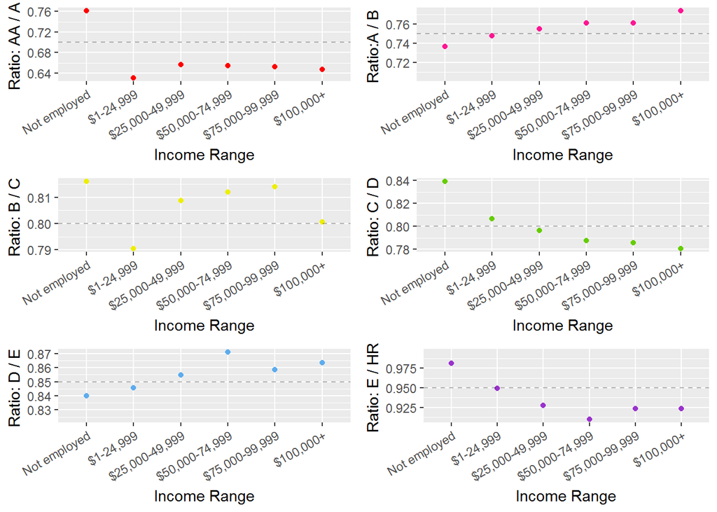

### Description Two

Loan Provider Profitability

This time I want to know how different between two similar prosper ratings. So I compared each pair of prosper ratings, such as: AA and A, A and B, etc. We can see the prosper rating ratio increases from 0.65 to 0.95. Especially, there is a big gap from AA/A to A/B.

In terms of the variety of income range, A/B and D/E ratio go up with the income range. B/C ratio goes up with the income range but significantly drop in the end. C/D and E/HR ratio go down with the income range. AA/A ratio almost stays the same.

Based on this diagram, we can find the perfect borrower APR for each borrower with differet income and prosper rating. This is also important for loan providers to measure their profitability.

### Plot Three

```
## # A tibble: 50 x 4
##    ProsperRating..Alpha. EstimatedLoss mean_CurrentDelinquencies     n
##    <fct>                         <dbl>                     <dbl> <int>
##  1 A                            0.0200                    0.235    888
##  2 A                            0.0210                    0.0665  1233
##  3 A                            0.0224                    0.0832   709
##  4 A                            0.0249                    0.168   1366
##  5 A                            0.0260                    0.196    403
##  6 A                            0.0274                    0.113   1049
##  7 A                            0.0299                    0.136   1304
##  8 A                            0.0324                    0.162   1199
##  9 A                            0.0325                    0.0943   106
## 10 A                            0.0330                    0.134    687
## # ... with 40 more rows
```

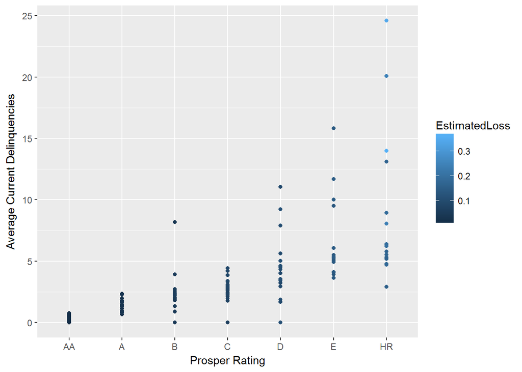

### Description Three

Credit Risk The estimated loss of AA prosper rating has the lowest delinquencies. The distribution of prosper rating B, C, E and HR is scattered distribution. The prosper rating HR has the highest estimated loss above 0.3 and the highest average current delinquencies over 24 times. This plot can show the credit risk and profit loss regarding different prosper rating of borrower. ——

# Reflection

In this report, I am glad to find the relationships between prosper rating and interest rate, delinquency and income range, delinquency and debt to income ratio, income range and loan amount.

In the future, I am keen to explore how to set a certain interest rate on different quality customers.